# 1-phase rectifier

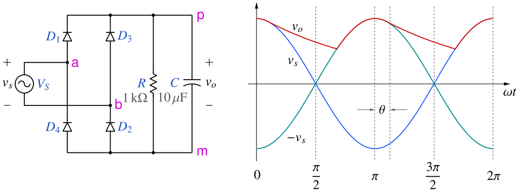

```python
from IPython.display import Image
Image(filename =r'rectifier_1ph_6_fig_1.png', width=800)
```

```python
# run this cell to view the circuit file.
%pycat rectifier_1ph_6_orig.in
```

We now replace the strings such as `\$R` with the values of our choice by running the python script given below. It takes an existing circuit file `rectifier_1ph_6_orig.in` and produces a new circuit file `rectifier_1ph_6.in`, after replacing `\$R` (etc) with values of our choice.

```python
import gseim_calc as calc
import numpy as np

s_R = "1000"
s_C = "10e-6"

l = [
  ('$R', s_R),
  ('$C', s_C),
]
calc.replace_strings_1("rectifier_1ph_6_orig.in", "rectifier_1ph_6.in", l)
print('rectifier_1ph_6.in is ready for execution')
```

```
rectifier_1ph_6.in is ready for execution
```

**Execute the following cell to run GSEIM on rectifier_1ph_6.in.**

```python
import os
import dos_unix
# uncomment for windows:
#dos_unix.d2u("rectifier_1ph_6.in")
os.system('run_gseim rectifier_1ph_6.in')
```

```
Circuit: filename = rectifier_1ph_6.in
main: calling solve_sss
solve_sss starting: sss_n_st: 1
solve_sss_ex: sss_iter_newton=0, rhs_sss_norm=1.0000e-04, sss_period_1_compute=4.0000e-02
solve_sss_ex: sss_iter_newton=1, rhs_sss_norm=0.0000e+00, sss_period_1_compute=4.0000e-02
solve_sss_ex: calling sss_solve_trns_ex for one more trns step
Transient simulation starts...
i=0
i=1000
GSEIM: Program completed.
```

```
0
```

The circuit file (`rectifier_1ph_6.in`) is created in the same directory as that used for launching Jupyter notebook. The last step (i.e., running `GSEIM` on `rectifier_1ph_6.in`) creates a data file called `rectifier_1ph_6.dat` in the same directory. We can now use the python code below to compute/plot the various quantities of interest.

```
filename: rectifier_1ph_6.dat
zero-crossing points of ID1 (positive slope):
    1.6780E-02
    3.6780E-02
zero-crossing points of ID1 (negative slope):
    1.0000E-03
    2.1000E-02
theta:  1.80E+01
```

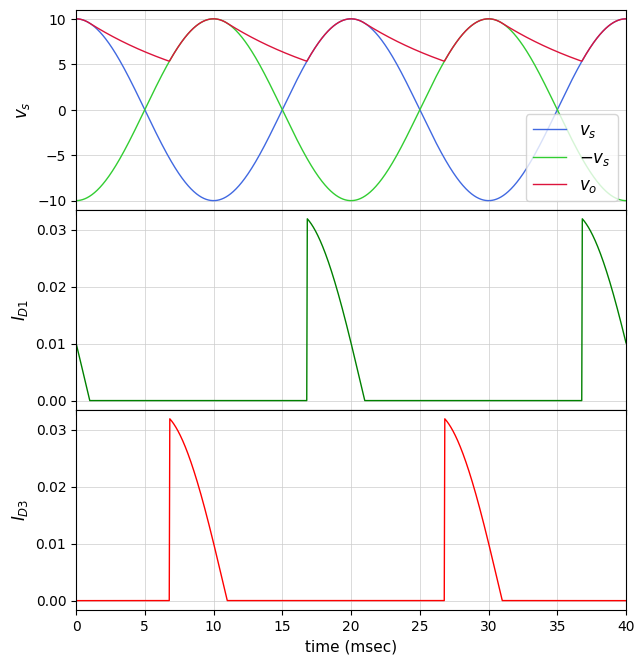

```python
import numpy as np
import matplotlib.pyplot as plt
import gseim_calc as calc
from setsize import set_size

f_hz = 50.0
T = 1.0/f_hz

slv = calc.slv("rectifier_1ph_6.in")

i_slv = 0
i_out = 0
filename = slv.l_filename_all[i_slv][i_out]
print('filename:', filename)
u = np.loadtxt(filename)
t = u[:, 0]

ID1 = slv.get_array_double(i_slv,i_out,"ID1",u)
ID3 = slv.get_array_double(i_slv,i_out,"ID3",u)
vs  = slv.get_array_double(i_slv,i_out,"vs",u)
vsm = slv.get_array_double(i_slv,i_out,"vsm",u)
v_o = slv.get_array_double(i_slv,i_out,"v_o",u)

l_cross_1_ID1, l_cross_2_ID1 = calc.cross_over_points_1(t, ID1, 0.0, 2.0*T, 1.0e-15)
print('zero-crossing points of ID1 (positive slope):')
for t1 in l_cross_1_ID1:
    print("  ", "%11.4E"%t1)
print('zero-crossing points of ID1 (negative slope):')
for t1 in l_cross_2_ID1:
    print("  ", "%11.4E"%t1)
theta = (l_cross_2_ID1[1]-T)*360.0/T
print("theta:", "%9.2E"%theta)

color1a = 'royalblue'
color1b = 'limegreen'
color1c = 'crimson'
color2  = 'green'
color3  = 'red'

fig, ax = plt.subplots(3, sharex=False)
plt.subplots_adjust(wspace=0, hspace=0.0)

set_size(5.5, 6, ax[0])

for i in range(3):
    ax[i].set_xlim(left=0.0, right=2.0*T*1e3)
    ax[i].grid(color='#CCCCCC', linestyle='solid', linewidth=0.5)

ax[0].set_ylabel(r'$v_s$',    fontsize=12)
ax[1].set_ylabel(r'$I_{D1}$', fontsize=12)
ax[2].set_ylabel(r'$I_{D3}$', fontsize=12)

ax[0].tick_params(labelbottom=False)
ax[1].tick_params(labelbottom=False)

ax[0].plot(t*1e3, vs , color=color1a, linewidth=1.0, label="$v_s$")
ax[0].plot(t*1e3, vsm, color=color1b, linewidth=1.0, label="$-v_s$")
ax[0].plot(t*1e3, v_o, color=color1c, linewidth=1.0, label="$v_o$")
ax[1].plot(t*1e3, ID1, color=color2 , linewidth=1.0, label="$I_{D1}$")
ax[2].plot(t*1e3, ID3, color=color3 , linewidth=1.0, label="$I_{D3}$")

ax[2].set_xlabel('time (msec)', fontsize=11)

ax[0].legend(loc = 'lower right',frameon = True, fontsize = 10, title = None,
  markerfirst = True, markerscale = 1.0, labelspacing = 0.5, columnspacing = 2.0,
  prop = {'size' : 12},)

#plt.tight_layout()
plt.show()
```

This notebook was contributed by **Prof. Nakul Narayanan K**, Govt. Engineering College, Thrissur. He may be contacted at nakul@gectcr.ac.in.